## Stat 771. Homework 3. Posted Friday, Oct 14, 2022.

# 1.

The Wasserstein distance between two cumulative distribution functions, $F_1$ and $F_2$, can be expressed
$$\int_{-\infty}^\infty | F_1(x) - F_2(x) | \, dx$$

# 1. a

Compute this distance in case $F_1$ and $F_2$ are two normal distributions, with constant variance $1$ and means $\mu_1 \neq \mu_2$.

# Answer to 1(a) - the Wasserstein distance of two normals

We first assume that $\mu_2 > \mu_1$, and derive:
$$\begin{align*}
\int_{-\infty}^{\infty}|F_1(x) - F_2(x)|dx & =
\int_{-\infty}^{\infty}|\Phi(x - \mu_1) - \Phi(x - \mu_2)|dx \\
& = \int_{-\infty}^{\infty}\Phi(x - \mu_1) - \Phi(x - \mu_2)dx \\
& = x(\Phi(x - \mu_1) - \Phi(x - \mu_2))|_{-\infty}^{\infty} -
\int_{-\infty}^{\infty} \Phi'(x - \mu_1) x dx +
\int_{-\infty}^{\infty} \Phi'(x - \mu_2) x dx \\
& =\int_{-\infty}^{\infty} \Phi'(x - \mu_1) x dx +
\int_{-\infty}^{\infty} \Phi'(x - \mu_2) x dx \\
& = \int_{-\infty}^{\infty} \Phi'(z) (z+\mu_2) dz +
\int_{-\infty}^{\infty} \Phi'(z) (z + \mu_1) dz \\
& = \mathbb{E}(z+ \mu_2) - \mathbb{E}(z+\mu_1) \\
& = \mu_2 - \mu_1 \\
\end{align*}$$
The second equality comes from the fact that the CDF is a non-decreasing function. The third equality comes from the integration by parts. The fifth equality comes from the change of variable that we set either $z = x - \mu_1$ or $z = x - \mu_2$. The sixth equality comes from that we know $\Phi' = \phi$ from the fundamental theorem of calculus.

# 1. b.

Compute this distance in case $F_1$ and $F_2$ are two exponential distributions, with rates $\alpha_1$ and $\alpha_2$.

# Answer to 1.(b)

Assume that $\alpha_2 > \alpha_1$, and recall that for an exponential $(\lambda)$ distribution with pdf:
$$\lambda e^{-\lambda x}$$
The CDF is:
$$1- e^{-\lambda x }$$
$$\begin{align}
\int_{0}^{\infty}|F_1(x) - F_2(x)|dx &=
\int_{0}^{\infty}|(1-e^{-\alpha_1 x}) - (1- e^{-\alpha_2}x)| dx \\
& = \int_{0}^{\infty}|e^{-\alpha_2x} - e^{-\alpha_1 x}| \\
& = \int_{0}^{\infty} e^{-\alpha_1 x} - e^{-\alpha_2 x }dx \\
& = \frac{-1}{\alpha_1}e^{-\alpha_1 x}|_{0}^{\infty} +
\frac{1}{\alpha_2} e^{-\alpha_2 x}|_{0}^{\infty} \\
& = \frac{1}{\alpha_1} - \frac{1}{\alpha_2}\\
\end{align}$$

# 1. c.

Compute this for two empirical distributions obtained from the synthetic data following part (d).

# Answer to 1.c

```r
set.seed(312345126)
F1 <- ecdf( rnorm(100) )
F2 <- ecdf( rnorm(100)+2/3 )

## form a sequence between -4 to 4 with step size 0.001

x = seq(-4,4,0.0001)

sum(abs(F1(x) - F2(x))*0.0001)
```

```
## [1] 0.600133
```

Note that the result is close to $\frac{2}{3}$, insights obtained from the derivation of part (a).

# 1. d.

In all three cases above, compute also the Kolmogorov metric $\rho=\max_{x}|F_1(x)-F_2(x)|$.

# Answer to 1.d

# Answer to 1.d.a - The Kolmogorov metric of two normals

Assume again that $\mu_2 > \mu_1$, then we have:
$$\rho = \max_{x}|\Phi(x- \mu_1) - \Phi(x-\mu_2)| = \max_{x} \Phi(x -
\mu_1) - \Phi(x - \mu_2)$$
To find the maximizer, take first order derivative with respect to $x$ and set to zero:
$$\begin{align*}
& \Phi'(x - \mu_1) - \Phi'(x-\mu_2) = 0 \\
& \rightarrow \frac{1}{\sqrt(2 \pi)}(e^{-\frac{(x - \mu_1)^2}{2}} -
e^{\frac{-(x - \mu_2)^2}{2}}) = 0 \\
& \rightarrow e^{-\frac{(x - \mu_1)^2}{2}} = e^{-\frac{(x -
\mu_2)^2)}{2}} \\
& \rightarrow \text{maximizer } x = \frac{\mu_1+ \mu_2}{2} \\
\end{align*}$$
As a result,
$$\max_{x} \Phi(x - \mu_1) - \Phi(x-\mu_2) = \Phi(\frac{\mu_2 - \mu_1}{2}
- \Phi(\frac{\mu_1 - \mu_2}{2})) = 1 - 2 \Phi(\frac{\mu_1 - \mu_2}{2})$$

# Answer to 1.d.b - Kolmogorov Metric to two exponentials

Assume that $\alpha_2 > \alpha_1$

$$\begin{align*}
\rho = \max_{x} |F_1(x) - F_2(x)| & = \max_{x} |e^{-\alpha_2 x} -
e^{\alpha_1 x}| \\
& = \max_{x} e^{\alpha_1 x} - e^{-\alpha_2 x} \\
\end{align*}$$

Take the first order derivative with respect to $x$ and set to zero:

$$\begin{align*}
& -\alpha_1 e^{-\alpha_1 x} + \alpha_2 e^{-\alpha_2 x} = 0 \\
& \rightarrow \alpha_2 e^{-\alpha_2 x} = \alpha_1 e^{-\alpha_1 x} \\
& \rightarrow (\alpha_1 - \alpha_2) x =
log(\frac{\alpha_1}{\alpha_2}) \\
& x = \frac{\log(\frac{\alpha_1}{\alpha_2})}{(\alpha_1 - \alpha_2)}
\\
\end{align*}$$

Thus, we can find the maximum:

$$\begin{align*}
\rho &= \max_{x} e^{-\alpha_1 x} - e^{- \alpha_2 x} \\
& = (\frac{\alpha_1}{\alpha_2})^{\frac{\alpha_1}{\alpha_2
-\alpha_1}} - (\frac{\alpha_1}{\alpha_2})^{\frac{\alpha_2}{\alpha_2 -
\alpha_1}} \\
\end{align*}$$

If we define $R = \frac{\alpha_1}{ \alpha_2}$, then we could simplify the expression into:
$$R^{\frac{R}{1-R}} - R^{\frac{1}{1-R}}$$

# Answer to 1(d)-(c), the Kolmogorov metric for the empirical distributions

Notice that we obtain $0.31$, and from the insight of our derivation for 1(d) - (a), for two normal with means $\mu_1$, $\mu_2$, and variance $1$, te Kolmogorov metric would be $1 - 2\Phi(\frac{\mu_1 - \mu_2}{2})$, take $\mu_1 = 0$ and $\mu_2 = \frac{2}{3}$,

$$1 - 2\Phi(\frac{\mu_1 - \mu_2}{2}) = 0.2611$$
Close to our simulation result.

```r
max(abs(F1(x) - F2(x)))
```

```
## [1] 0.31
```

```r
1 - 2*pnorm(0.5*(0-2/3))
```

```
## [1] 0.2611173
```

# 2.

A random variable $X$ takes on one of three possible values, with probabilities $p=(p_1, p_2, p_3)$, with $p_j \geq 0$ and $p_1+p_2 +p_3=1$. A one parameter model for this distribution has probabilities $q_\theta=( (2+\theta)/4, (1-\theta)/2, \theta/4)$, where $\theta \in [0,1]$. With $p$ fixed, find the value of $\theta$ to minimize the Kullback-Leibler divergence of $p$ from $q$, KL$(p||q) = \sum_j p_j \log(p_j/q_{\theta,j})$.

# Answer to 2

Evaluate the KL divergence.
$$\begin{align*}
\sum_{j} p_j \log(\frac{p_j}{q_{\theta,j}}) & = p_1(\log(\frac{4
p_1}{2+\theta})) + p_2 \log(\frac{2 p_2}{1-\theta}) + p_3 \log(\frac{4
p_3}{\theta}) \\
& = \text{constant} + p_1(\log(\frac{1}{2+\theta})) + p_2
\log(\frac{1}{1 - \theta}) + (1-p_1 - p_2) \log(\frac{1}{\theta}) \\
\end{align*}$$
The last equality comes from the constraint $p_1+ p_2+p_3 = 1$, and we set the terms irrelevant to $\theta$ as constant.

Take first order derivative with respect to $\theta$, and set to zero:
$$\begin{align*}
& - p_1(\frac{1}{2 + \theta}) + p_2 \frac{1}{1-\theta} + (p_1+p_2
-1)\frac{1}{\theta} = 0 \\
& \rightarrow p_1(\theta - 1) \theta + p_2(\theta^2 + 2 \theta)
+(p_1 + p_2 - 1)(-\theta^2 - \theta +2) = 0 \\
& \rightarrow \theta^2 +(1-2 p_1 + p_2) + 2(p_1+ p_2 -1) = 0 \\
& \theta = \frac{-1(1-2 p_1 + p_2)+ \sqrt{(1- 2 p_1 + p_2)^2 - 8(p_1
+ p_2 -1)}}{2} \\
\end{align*}$$

## Simulation to verify the result

```r
p1 = 0.2
p2 = 0.5
p3 = 0.3
pseq = c(p1,p2,p3)
theta = seq(0,1,0.01)
KL <- function(theta,pseq){
  qtheta <-c((2+theta)/4, (1-theta)/2, theta/4)
  log_seq = log(pseq/qtheta)
  KL_diver = sum(pseq*log_seq)
  return(KL_diver)
}

KL_v = Vectorize(KL,vectorize.args = "theta")
divergence = KL_v(theta,pseq)
argmin.theta = theta[which.min(divergence)]

theory.theta = 0.5*((-1)*(1-2*p1+p2)+sqrt((1-2*p1+p2)^2-8*(p1+p2-1)))

cbind(argmin.theta,theory.theta)
```

```
##      argmin.theta theory.theta
## [1,]          0.4          0.4
```

# 3.

Let $X$ be an $n \times p$ design matrix and $y$ an $n \times 1$ response vector. For a scaler $\lambda \geq 0$ the ridge regression estimator $\beta^{\rm ridge}$ minimizes the following objective function:

$$f(\beta) = (y-X \beta)^T (y-X\beta) +
\lambda \beta^T \beta$$

# a.

Show that $\beta^{\rm ridge}$ satisfies

$$(X^T X + \lambda I) \beta^{\rm ridge} =
X^T y$$
where $I$ is the $p \times p$ identity matrix.

# Answer to 3.a

We take the first order derivative with respect to $\beta$ and set to zero:

$$\begin{align*}
& \frac{\partial f(\beta)}{\partial \beta}=0 \\
& \rightarrow -2 X^T(y- X \beta^{\rm ridge}) + 2 \lambda \beta^{\rm
ridge} = 0 \\
& \rightarrow X^T y = (X^T X + \lambda I) \beta^{\rm ridge} \\
\end{align*}$$

# b.

Write the resulting predicted values $X \beta^{\rm ridge}$ in terms of the response vector, and the left singular vectors and the singular values of $X$. Comment on the effect of $\lambda$.

# Answer to 3.b

The singular value decomposition of $X$ gives:
$$X = U \times D \times V^T$$
For $U: n \times n$; $D: n \times p$, $V: p \times p$. $U$ and $V$ are orthonormal matrices. In particular:
$U^T U = U U^T = I_{n}$. $V^T V = VV^T= I_{p}$. $D_{ii} =\sigma_i$ for $i \leq \text{rank}(X) \leq p$.

Thus we have:

$$\beta^{\rm ridge} = (X^T + \lambda I)^{-1}X^Ty = (V D^2 V^T + \lambda
I)^{-1} V D^T U^T y$$

and:
$$X \beta^{\rm ridge} = U D V^T(V D^2 V^T + \lambda I)
^{-1} V D^T U^T y = \sum_{j=1}^n (\frac{\sigma_j^2}{\sigma^2_j+
\lambda}) U_i U_i^T y_i$$
By we noticing that $V^TV = I_p$, and $U_i U_j = 0$ for $i \neq j$.

# c.

Note the quantity $\delta (\lambda) = \sum_{j=1}^p \sigma_j^2/(\sigma_j^2 + \lambda)$. For the prostate cancer data set used in homework 2, consider ridge regression estimates for eight predictors predicting `lpsa`, the level of prostate-specific antigen, and plot the estimated coefficient on one panel as a function of $\delta(\lambda)$. Use $\lambda$ values so that $\delta$ ranges between 0 and 8.

# Answer to 3.c

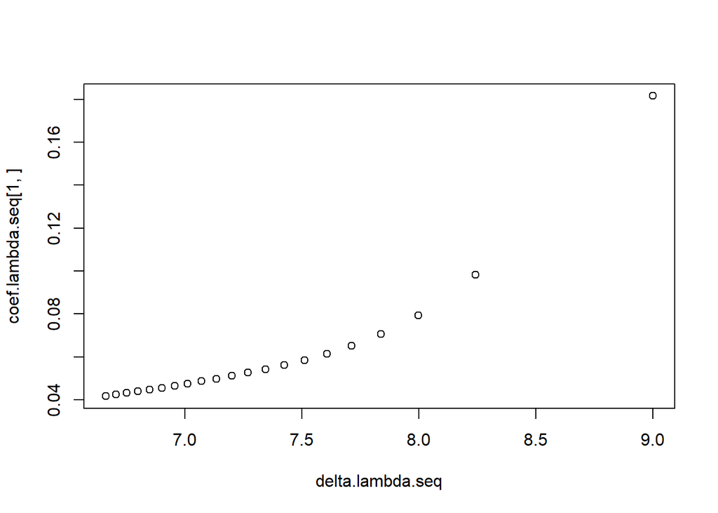

```r
prostate = read.table("http://statweb.stanford.edu/~tibs/ElemStatLearn/datasets/prostate.data")

# First obtain the design matrix
X = cbind(rep(1,97), prostate[,-c(9,10)])
Y = prostate$lpsa
svd.pros = svd(X)

U = svd.pros$u
D = diag(svd.pros$d)
V = svd.pros$v
# create a function to compute the coefficients corresponding to each lambda
coef.prostate.ridge <-function(lambda){
  coeff<-solve(V%*%t(D)%*%D%*%t(V)+lambda*diag(x=1,nrow=9))%*%V%*%t(D)%*%t(U)%*%Y

}

coef.prostate.ridge.V = Vectorize(coef.prostate.ridge,vectorize.args = "lambda")

## consider different lambda
lambda<-seq(0,10,0.5)

delta.lambda <-function(lambda){

  value = sum((svd.pros$d)^2/((svd.pros$d)^2+lambda))
  return(value)
}
delta.lambda.V = Vectorize(delta.lambda,vectorize.args = "lambda")

delta.lambda.seq = delta.lambda.V(lambda)
coef.lambda.seq = coef.prostate.ridge.V(lambda)

plot(delta.lambda.seq,coef.lambda.seq[1,])
```

# 4.

Consider two independent Binomially distributed random variables, $X_1$ and $X_2$, both on $m=5$ trials, but arising from possibly different success probabilities $\theta_1$, and $\theta_2$. We know from external information that $\theta_1 \leq \theta_2$, but their actual values are unknown. Using first-order optimality, find the maximum likelihood estimate of these parameters in case $x_1=1$ and $x_2=2$. Do so also in the case $x_1=2$ and $x_2=1$.

# Answer to 4

the likelihood function with $m=5$ is:
$$f(\theta_1, \theta_2) = {5 \choose{x_1}}{5 \choose{x_2}}
\theta_1^{x_1}(1-\theta_1)^{5-x_1} \theta_2^{x_2}
(1-\theta_2)^{5-x_2}I_{(\theta_1 \leq \theta_2)}$$
if we take log and take first order derivative with respect to $\theta_1$ and $\theta_2$ and set to zero:

$$x_1 \frac{1}{\theta_1} + (5 - x_1)\frac{1}{\theta_1 - 1} = 0$$

$$x_2 \frac{1}{\theta_2} + (5 - x_2)\frac{1}{\theta_2 - 1} = 0$$

then we can get $\theta_1 = \frac{1}{5}$; $\theta_2 = \frac{2}{5}$. However, when $x_2 \leq x_1$, we need to take $\theta_1 =\theta_2 = \frac{x_2}{5} = \frac{1}{5}$.

# 5.

Confirm mathematically which ones of the following sets are convex:

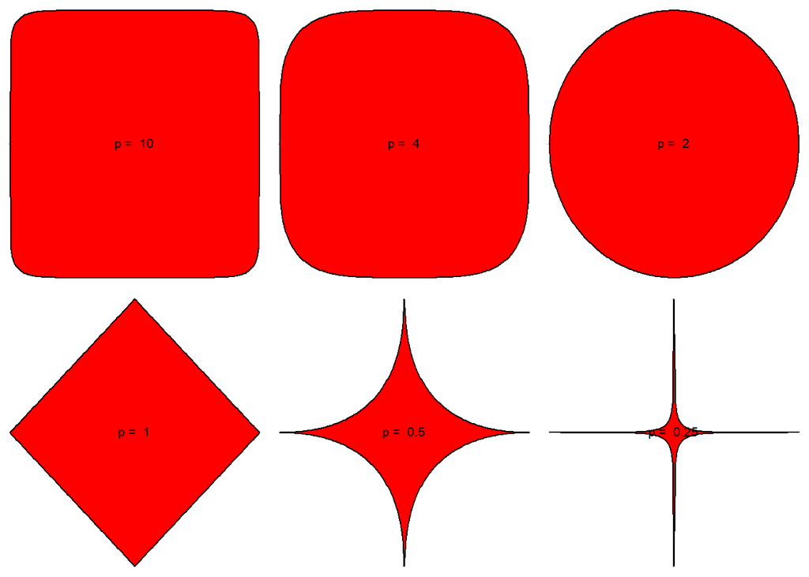

```r
# draw sets where ( x^p + y^p )^(1/p) <=  cc
# x^p + y^p = cc^p
# y^p = cc^p - x^p
# y = (cc^p - x^p)^(1/p)

par( mfrow=c(2,3), mar=rep(0,4) )

p <- 10
x <- seq(-1,1,by=.01)
y <- (1-abs(x)^p)^(1/p)
u <- c(x,rev(x))
v <- c(y,-y)
plot(u,v,type="n",axes=FALSE)
polygon(u,v, col="red" )
text(0,0,paste("p = ", format(p, digits=2) ) )

p <- 4
x <- seq(-1,1,by=.01)
y <- (1-abs(x)^p)^(1/p)
u <- c(x,rev(x))
v <- c(y,-y)
plot(u,v,type="n",axes=FALSE)
polygon(u,v, col="red" )
text(0,0,paste("p = ", format(p, digits=2) ) )

p <- 2
x <- seq(-1,1,by=.01)
y <- (1-abs(x)^p)^(1/p)
u <- c(x,rev(x))
v <- c(y,-y)
plot(u,v,type="n",axes=FALSE)
polygon(u,v, col="red" )
text(0,0,paste("p = ", format(p, digits=2) ) )


p <- 1
x <- seq(-1,1,by=.01)
y <- (1-abs(x)^p)^(1/p)
u <- c(x,rev(x))
v <- c(y,-y)
plot(u,v,type="n",axes=FALSE)
polygon(u,v, col="red" )
text(0,0,paste("p = ", format(p, digits=2) ) )


p <- 1/2
x <- seq(-1,1,by=.01)
y <- (1-abs(x)^p)^(1/p)
u <- c(x,rev(x))
v <- c(y,-y)
plot(u,v,type="n",axes=FALSE)
polygon(u,v, col="red" )
text(0,0,paste("p = ", format(p, digits=2) ) )

p <- 1/4
x <- seq(-1,1,by=.01)
y <- (1-abs(x)^p)^(1/p)
u <- c(x,rev(x))
v <- c(y,-y)
plot(u,v,type="n",axes=FALSE)
polygon(u,v, col="red" )
text(0,0,paste("p = ", format(p, digits=2) ) )
```

# Answer to 5

We first fix the notations. Notice that the graphed sets are in $\mathbb{R}^2$. We use the letter $Z$ to denote the component in $\mathbb{R}^2$, and let $Z = (X,Y)$, $X$ and $Y$ are the scalars inside each tuple.
The graphed sets are defined by different $p$ such that:
$$(X^p + Y^p)^{\frac{1}{p}} \leq c$$
Finally, denote the set defined with $p = p_0 = S_{p_0}$. For example, the set $Z \in \mathbb{R}^2$, $Z = (X,Y)$ such that $(X^8+Y^8)^{\frac{1}{8}} \leq C$ is called $S_{8}$.

Now we start our proofs.
Notice that from Minkowski inequality, for $1 \leq p \leq \infty$, we have:
$$(\sum_{k=1}^n|x_k+y_k|^p)^{\frac{1}{p}} \leq (\sum_{k=1}^n
|x_k|^p)^{\frac{1}{p}} + (\sum_{k=1}^n |y_k|^p)^{\frac{1}{p}}$$
In other words, for all $1 \leq p \leq \infty$, the $L^p$ norm satisfies the triangle inequality that for $Z_1$ and $Z_2 \in \mathbb{R}^n$:
$$\|Z_1 + Z_2\|_{p} \leq \|Z_1\|_{p} + \|Z_2\|_{p}$$

And notice that in cases that $p$ is even, $\|Z_1\|_p = (X_1^p + Y_1^p)^{\frac{1}{p}}$.  
Then to prove the cases $p = 10,4,2$ are convex sets.  
Let $Z_1$ and $Z_2 \in S_{p}$,

$$\begin{align*}
\| \alpha Z_1 + (1- \alpha) Z_2\|_{p} & \leq |\ \alpha Z_1\|_{p} +
\|(1- \alpha) Z_2\|_{p} \\
& = \alpha \|Z_1\|_p + (1-\alpha)\|Z_2\|_{p} \\
& \leq C
\end{align*}$$
For $\alpha \in (0,1)$. Which implies that if we have $Z_1 \in S_p$ and $Z_2 \in S_p$, then $\alpha Z_1 + (1- \alpha) Z_2 \in S_p$, for $p \ge 1$ and even.

For $p=1$,
Notice that $Z_1 = (X_1, Y_1)$, $Z_2 = (X_2,Y_2) \in S_1$ implies that:
$$|X_1| + |Y_1| \leq C$$
and
$$|X_2| + |Y_2| \leq C$$
Then:
$$|\alpha Z_1 + (1-\alpha)Z_2| \leq |\alpha Z_1| +|(1-\alpha)Z_2| = \alpha
|Z_1| + (1-\alpha)|Z_2| = \alpha (|X_1| + |Y_1|) + (1- \alpha)(|X_2|+
|Y_2|) \leq C$$
Consequently, $p = 1$ also gives a convex set.
For $p=0.5, 0.25$, we give counter examples to show it is not convex.
Suppose for $p=0.5$, we define the set to be $Z \in \mathbb{R}^2 = (X,Y)$ such that:
$$(X^{0.5} + Y^{0.5})^2 \leq 1$$
Then take $Z_1 = (1,0)$, $Z_2 = (0,1)$ in the set, but take $\alpha = 0.5$,
$$\alpha Z_1 + (1-\alpha)Z_2 = (0.5,0.5)$$

$$(0.5^{0.5}+ 0.5^{0.5})^2 >1$$
not in the set.

Similarly, for $p=0.25$, we can still take $Z_1 = (1,0)$, $Z_2 = (0,1)$, they are in the set of:
$$(X^{0.25}+ Y^{0.25})^4 \leq 1$$
But $\alpha Z_1+ (1-\alpha)Z_2 = (0.5,0.5)$ has:
$$(0.5^{0.25}+ 0.5^{0.25})^4 =8 >1$$
Not in the set.